# A short note on stochastic simulations: a glimpse on the rejection method

R. Monteiro[^1]

10/2/2018

## Generating some random variables using inverse function method

Furthermore, we know that
$$X = F^{-1}(U)$$
is an exponential distribution, we only need to simulate a uniform on the interval [0,1]. Hence, we first generate an uniform random variable U

```r
U = runif(1,min=0,max=1);
```

Now we use the inverse function in . It is not hard to show that
$$\begin{align}
F^{-1}(u) = -\frac{1}{\lambda}log(1-u).
\end{align}$$
which can be simplified to
$$\begin{align}
F^{-1}(u) = -\frac{1}{\lambda}log(u).
\end{align}$$

if you note that 1-U and U both have uniform distribution in $[0,1].$ Ok, now we are ready to generate our exponential distribution:

```r
generate_exponential <- function(lambda){
U = runif(1,min=0,max=1);
  X = -(1/lambda)*log(U);
return (X);  }
```

We are going to generate 1000 exponentially distributed random variables.

```r
N = 1000;
X <- matrix(0,N,1);
lambda =.5;
for (i in 1:N ){
  X[i] = generate_exponential(lambda);
}
```

Just for verification, I will plot a histogram with these values. Note how close to the density they are (a good sign,right?).

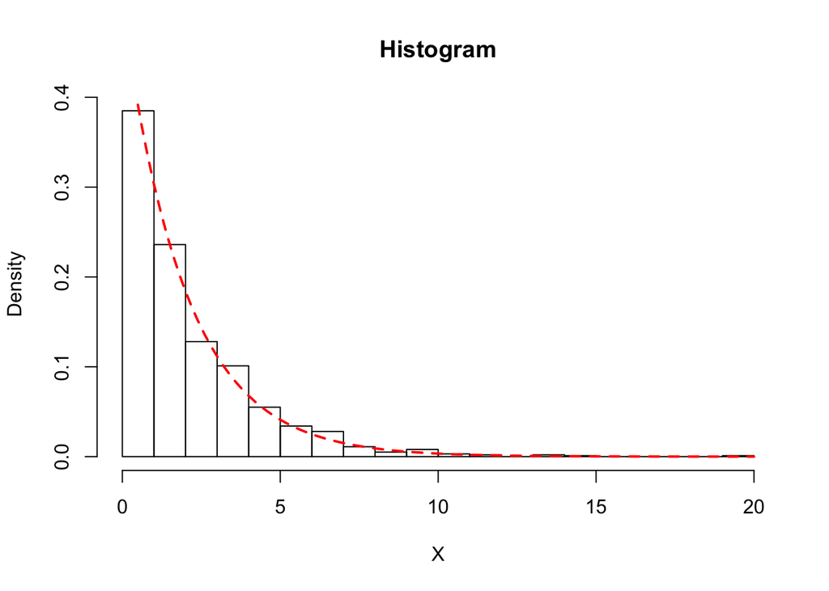

```r
hist(X, breaks=25,main="Histogram", prob =TRUE)
curve(dexp(x,rate=lambda), add=TRUE, col = 2, lty = 2, lwd = 2)
```

## A case that is not contemplated by the previous method

Now we shall consider a case that does not fit the previous technique. To begin with, imagine that you want to simulate a random variable X on the interval $[0,1]$ that has the following density function:
$$\begin{align}
f_X(x) = cx^2(1 - x)^2.
\end{align}$$

I’ll first create the function f:

```r
f <- function(x) {
  result= 30*x^2*(1-x)^2;
  return(result)
}
```

The constant $c$ is so that $\int_0^1 f(s)\mathrm{d}s =1$. This can be found using integration (or any symbolic package, like SAGE): in fact, $c=30$.

The idea is that, if you generate another distribution Y with density function $g(\cdot)$ and so that

$$\frac{f(x)}{g(x)}\leq M$$

(be careful, this is a pointwise bound! In other words, this is a severely tying/constraining both distributions X and Y!). In our case, $g(\cdot) =1$, and it is not hard to show that $M = \frac{30}{16}$ (a crude bound would be $M=30$, but smaller values are better (the reason why is that the acceptance rate of the method below behaves as a geometric distribution with rate $\frac{1}{M}$). Now we do the following:

- Step 1: Generate a random variable with distribution Y;
- Step 2: Generate an Uniform r.v. U;
- Step 3: If $U \leq \frac{f(Y)}{cg(Y)}$ then do X =Y, otherwise go back to step 1

Ok, now we are ready to go. Notice that we must simulate until we get a valid result

```r
M = 30/16;
Y = matrix(0,N,1);
for (i in 1:N){
  while (TRUE){
    U = runif(2, min=0,max=1);
    if (U[2] <f(U[1])/M){
      Y[i]= U[1];
      break;
    }
  }

}
```

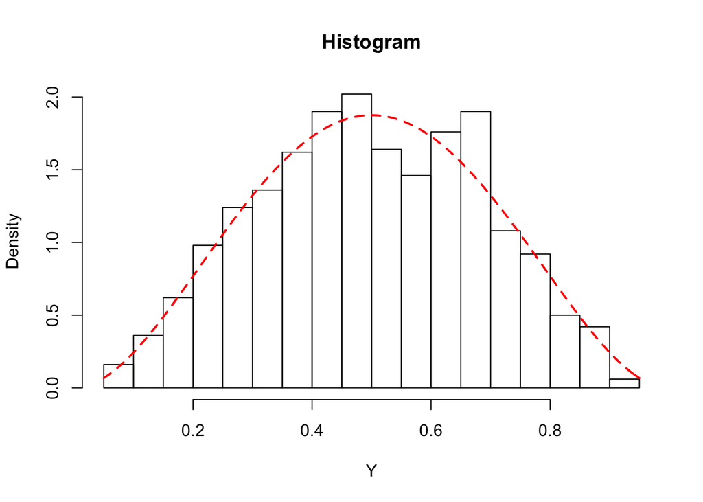

```r
hist(Y, breaks=25,main="Histogram", prob =TRUE)
curve(f(x), add=TRUE, col = 2, lty = 2, lwd = 2)
```

[^1]: Mathematics for Advanced Materials - Open Innovation Lab, Japan. Email: rafael.a.monteiro.math@gmail.com, monteirodasilva-rafael@aist.go.jp